# R Notebook

Load essential packages:

```r
library(lwgeom)
library(readr)
library(sf)
library(stargazer) # for quickly creating tables with model results
library(tidyverse)
library(units)
```

#— A) Preparing the School Profiles object and relating gross floor area to capacity

Read the data from the csv file:

```r
School_Profiles <- read.csv("School-Profiles.csv")

School_Profiles %>%
  summary()
```

```
 school_name            Type              Grades          Location.in.Hamilton
 Length:89          Length:89          Length:89          Length:89
 Class :character   Class :character   Class :character   Class :character
 Mode  :character   Mode  :character   Mode  :character   Mode  :character




      year        enrolment         capacity      utilization_rate
 Min.   :2011   Min.   :  61.0   Min.   : 181.0   Min.   :0.3400
 1st Qu.:2012   1st Qu.: 174.5   1st Qu.: 250.0   1st Qu.:0.5850
 Median :2017   Median : 254.0   Median : 348.0   Median :0.6900
 Mean   :2016   Mean   : 361.6   Mean   : 498.4   Mean   :0.6946
 3rd Qu.:2020   3rd Qu.: 364.0   3rd Qu.: 633.0   3rd Qu.:0.7900
 Max.   :2022   Max.   :1648.0   Max.   :1569.0   Max.   :1.1400
                NA's   :2                         NA's   :2
  portables           Site.Acres     Building.Gross..Ft2.     gym
 Length:89          Min.   : 1.700   Length:89            Length:89
 Class :character   1st Qu.: 4.045   Class :character     Class :character
 Mode  :character   Median : 5.410   Mode  :character     Mode  :character
                    Mean   : 7.436
                    3rd Qu.: 8.955
                    Max.   :42.970
                    NA's   :2
 gym.with.stage     Number.of.gyms  Computer.lab       Childcare.Centre.on.site
 Length:89          Min.   :1.000   Length:89          Length:89
 Class :character   1st Qu.:1.000   Class :character   Class :character
 Mode  :character   Median :1.000   Mode  :character   Mode  :character
                    Mean   :1.333
                    3rd Qu.:1.000
                    Max.   :4.000
                    NA's   :8
  auditorium         rec_centre            pool             Library
 Length:89          Length:89          Length:89          Length:89
 Class :character   Class :character   Class :character   Class :character
 Mode  :character   Mode  :character   Mode  :character   Mode  :character




  Cafeteria           Document
 Length:89          Length:89
 Class :character   Class :character
 Mode  :character   Mode  :character
```

We are interested in capacity (for year 2011 or 2012, as those are un-projected values) and area, so we will remove duplicates of these variables (we’ll also rename `Building Gross (Ft2)` simply `area`):

```r
School_Profiles_u <- School_Profiles %>%
  rename(area = `Building.Gross..Ft2.`) %>%
  distinct(capacity,
           area,
           .keep_all = TRUE) # Keep all columns
```

Drop a few inaccurate school records, reformat the area column, and convert area from ft^2 to m^2 to match footprint units:

```r
School_Profiles_u <- School_Profiles_u %>%
  drop_na(area)

School_Profiles_u <- School_Profiles_u [ !(School_Profiles_u$school_name %in% "New Spencer Valley"),]

School_Profiles_u <- School_Profiles_u [ !(School_Profiles_u$school_name %in% "Rockton Elementary"),]


School_Profiles_u$area <- sub(",", "", School_Profiles_u$area)
School_Profiles_u$area <- as.numeric(as.character(School_Profiles_u$area))

School_Profiles_u <- School_Profiles_u %>%
    mutate(area = set_units(area, ft^2),
         area = set_units(area, m^2))
```

Visualize area and capacity in a scatterplot:

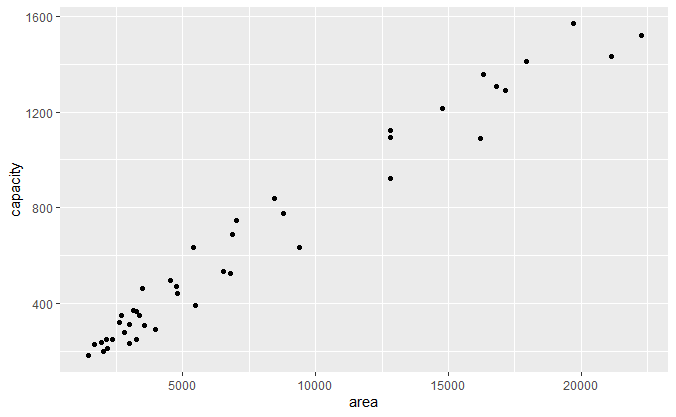

```r
ggplot(data = School_Profiles_u %>%
         mutate(area = drop_units(area)),
       aes(x = area,
           y = capacity)) +
  geom_point()
```

Schools with larger gross floor areas have greater capacity, and there appears to be a strong linear relationship between these two variables. Now let’s see how the building footprints relate to capacity.

#— B) Importing School Points and comparing footprint to capacity (from School Profiles)

Import DSB_1011_Comp (the School Points for 2010-2011 Public Schools in HWDSB):

```r
load("DSB_1011_Comp.RData")
```

Join the DSB_1011 table to the school profiles:

```r
School_Profiles_u <- School_Profiles_u %>%
  left_join(DSB_1011_Comp, by = c("school_name" = "SCHNAME"))
```

Reformat school profiles and plot:

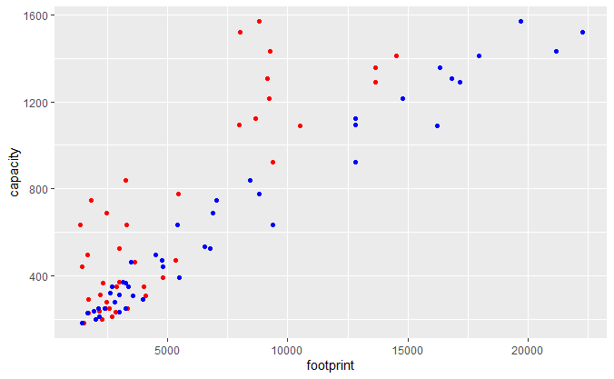

```r
School_Profiles_u %>%
  mutate(area = drop_units(area),
         footprint = drop_units(footprint)) %>%
  ggplot() +
    geom_point(aes(x = footprint, y = capacity), colour = 'red') +
    geom_point(aes(x = area, y = capacity), colour = 'blue')
```

So the footprint vs. capacity (red) appears to have a less linear relationship (more steep) than area vs. capacity (blue).

How strong is the linear relationship? We can calculate the correlation:

```r
School_Profiles_u %>%
  select(capacity,
         area,
         footprint) %>%
  drop_na() %>%
  cor()
```

```
           capacity      area footprint
capacity  1.0000000 0.9820622 0.8579781
area      0.9820622 1.0000000 0.8601001
footprint 0.8579781 0.8601001 1.0000000
```

capacity - footprint, 0.86 corr coeff capacity - area, 0.98 corr coeff

Footprint isn’t highly correlated as area but it definitely worth exploring.

#— C) Building a univariate regression model to predict On The Ground Capacity (OTGC)

Estimate a univariate regression model:

```r
OTG_fit_footprint <- lm(capacity ~ footprint,
              data = School_Profiles_u %>%
                drop_na(footprint))

summary(OTG_fit_footprint)
```

```
Call:
lm(formula = capacity ~ footprint, data = School_Profiles_u %>%
    drop_na(footprint))

Residuals:
    Min      1Q  Median      3Q     Max
-259.85 -181.37  -90.96  142.10  554.35

Coefficients:
             Estimate Std. Error t value Pr(>|t|)
(Intercept) 1.497e+02  5.935e+01   2.523   0.0157 *
footprint   1.019e-01  9.648e-03  10.564 3.88e-13 ***
---
Signif. codes:  0 ‘***’ 0.001 ‘**’ 0.01 ‘*’ 0.05 ‘.’ 0.1 ‘ ’ 1

Residual standard error: 229.5 on 40 degrees of freedom
Multiple R-squared:  0.7361,    Adjusted R-squared:  0.7295
F-statistic: 111.6 on 1 and 40 DF,  p-value: 3.882e-13
```

Theoretically we know the intercept should be zero (OTGC=0 when footprint is 0). We force the regression line to pass through the origin. Let’s compare the footprint and the area models:

```r
OTG_fit_area <- lm(capacity ~ 0 + area,
                            data = School_Profiles_u)

OTG_fit_footprint <- lm(capacity ~ 0 + footprint,
                            data = School_Profiles_u %>%
                drop_na(footprint))

stargazer::stargazer(OTG_fit_area, OTG_fit_footprint, type = "text")
```

[output not shown]

```
=====================================================================
                                   Dependent variable:
                    -------------------------------------------------
                                        capacity
                               (1)                      (2)
---------------------------------------------------------------------
area                        0.078***
                             (0.002)

footprint                                            0.121***
                                                      (0.006)

---------------------------------------------------------------------
Observations                   43                       42
R2                            0.980                    0.906
Adjusted R2                   0.980                    0.903
Residual Std. Error     110.354 (df = 42)        244.091 (df = 41)
F Statistic         2,106.921*** (df = 1; 42) 393.443*** (df = 1; 41)
=====================================================================
Note:                                     *p<0.1; **p<0.05; ***p<0.01
```

Plot predictions:

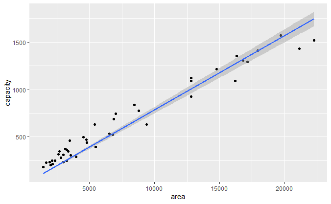

```r
ggplot(data = School_Profiles_u %>%
         mutate(area = drop_units(area)),
       aes(x = area,
           y = capacity)) +
  geom_point() +
  geom_smooth(formula = y ~ 0 + x,
              method = "lm")
```

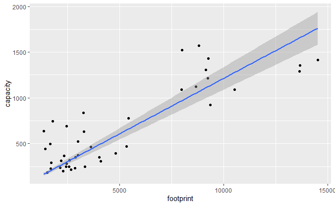

```r
ggplot(data = School_Profiles_u %>%
         mutate(footprint = drop_units(footprint)),
       aes(x = footprint,
           y = capacity)) +
  geom_point() +
  geom_smooth(formula = y ~ 0 + x,
              method = "lm")
```

It’s clear area better predicts OTGC than footprint. As gross floor area is unavailable for all the datapoints, additional predictors will be added to the footprint predictors to try to improve accuracy and precision.

#— D) Building a multivariate regression model to predict On The Ground Capacity (OTGC)

Add potential predictor variables to the School Profiles object.

First, add a ‘proxy’ for age of construction. Assuming schools constructed closer to the CBD (the lat-long coordinate of "King St W and James St S: (43.256684, -79.869039)) is older and further away is newer.

```r
urban_pt <- st_sfc(st_point(c(-79.869039, 43.256684)), crs=4326 )
DSB_1011_Comp_WSG84 <- st_transform(DSB_1011_Comp, crs=4326)

DSB_1011_Comp$urban.dist <- st_distance(DSB_1011_Comp_WSG84, y = urban_pt)

School_Profiles_u <- left_join(School_Profiles_u,DSB_1011_Comp[, c("SCHNAME", "urban.dist")], by = c("school_name" = "SCHNAME"))
```

Next add School Type and school Grade dummy variables:

```r
School_Profiles_u <- School_Profiles_u %>%
  mutate(Type.Elementary = ifelse(Type == "Elementary" | Type == "Middle", 1, 0),
         Type.Secondary = ifelse(Type == "Secondary", 1, 0),
         Grades.6to8 = ifelse(Grades == "(6-8)", 1, 0),
         Grades.JKto5 = ifelse(Grades == "(JK-5)", 1,0),
         Grades.JKto6 = ifelse(Grades == "(JK-6)", 1, 0),
         Grades.JKto5_6 = ifelse(Grades == "(JK-5)" | Grades == "(JK-6)", 1,0),
         Grades.JKto8 = ifelse(Grades == "(JK-8)", 1, 0),
         Grades.9to12 = ifelse(Grades == "(9-12)", 1, 0))
```

Attempt different multi-variate regression models and decide upon this one:

```r
OTG_fit_DSB <- lm(log(capacity) ~ 0 + log(footprint) + Grades.JKto5_6 + Grades.JKto8 + Grades.6to8 + Grades.9to12 + urban.dist,
                            data = School_Profiles_u %>%
                drop_na(footprint))

OTG_fit_CDSB <- lm(log(capacity) ~ 0 + log(footprint) + Type.Elementary + Type.Secondary + urban.dist,
                            data = School_Profiles_u %>%
                drop_na(footprint))

stargazer::stargazer(OTG_fit_DSB,OTG_fit_CDSB, type = "text")
```

[output not shown]

```
=======================================================================
                                    Dependent variable:
                    ---------------------------------------------------
                                       log(capacity)
                               (1)                       (2)
-----------------------------------------------------------------------
log(footprint)              0.277***                   0.308**
                             (0.102)                   (0.150)

Grades.JKto5_6              3.684***
                             (0.785)

Grades.JKto8                4.355***
                             (0.802)

Grades.6to8                 3.640***
                             (0.851)

Grades.9to12                4.746***
                             (0.923)

Type.Elementary                                       3.652***
                                                       (1.173)

Type.Secondary                                        4.442***
                                                       (1.359)

urban.dist                 -0.00003***               -0.00003**
                            (0.00001)                 (0.00001)

-----------------------------------------------------------------------
Observations                   42                        42
R2                            0.999                     0.997
Adjusted R2                   0.999                     0.997
Residual Std. Error      0.219 (df = 36)           0.351 (df = 38)
F Statistic         5,776.183*** (df = 6; 36) 3,372.737*** (df = 4; 38)
=======================================================================
Note:                                       *p<0.1; **p<0.05; ***p<0.01
```

These two models have the most accurate adjusted R-Squared, lowest standard error and most significant predictors. DSB points have grade information while CDSB only have “elementary” or “secondary” denomonations, hence the two models.

Check the residuals for the models:

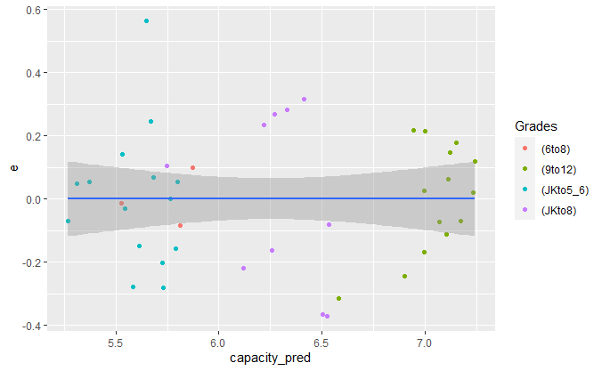

```r
ggplot(data.frame(e = OTG_fit_DSB$residuals,
                  capacity_pred = OTG_fit_DSB$fitted.values,
                  Grades = case_when(OTG_fit_DSB$model$Grades.JKto5_6 == 1 ~ "(JKto5_6)",
                                     OTG_fit_DSB$model$Grades.6to8 == 1 ~ "(6to8)",
                                     OTG_fit_DSB$model$Grades.JKto8 == 1 ~ "(JKto8)",
                                     OTG_fit_DSB$model$Grades.9to12 == 1 ~ "(9to12)")),
       aes(x = capacity_pred, y = e)) +
  geom_point(aes(color = Grades)) +
  geom_smooth(method = "lm")
```

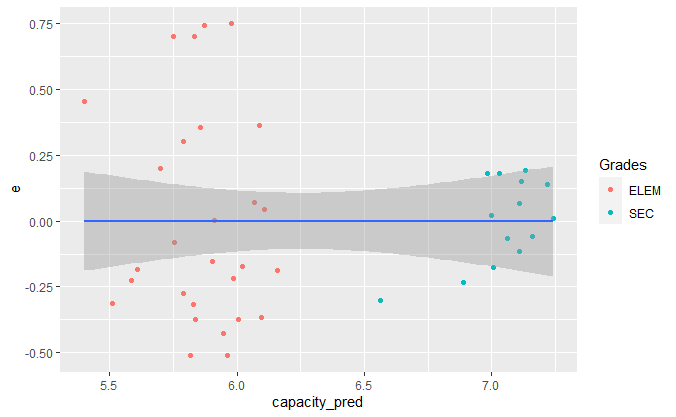

```r
ggplot(data.frame(e = OTG_fit_CDSB$residuals,
                  capacity_pred = OTG_fit_CDSB$fitted.values,
                  Grades = case_when(OTG_fit_CDSB$model$Type.Elementary == 1 ~ "ELEM",
                                     OTG_fit_CDSB$model$Type.Secondary == 1 ~ "SEC")),
       aes(x = capacity_pred, y = e)) +
  geom_point(aes(color = Grades)) +
  geom_smooth(method = "lm")
```

Transform the predicted values back from their log transformation and plot:

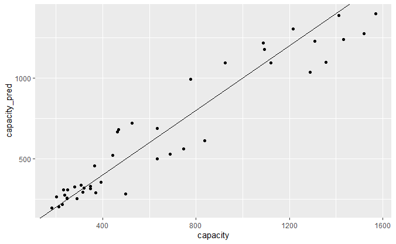

```r
capacity_pred <- data.frame(capacity = exp(OTG_fit_DSB$model$`log(capacity)`),
                            capacity_pred = exp(OTG_fit_DSB$fitted.values))

ggplot(capacity_pred,
       aes(x = capacity, y = capacity_pred)) +
  geom_point() +
  geom_abline(intercept = 0, slope = 1)
```

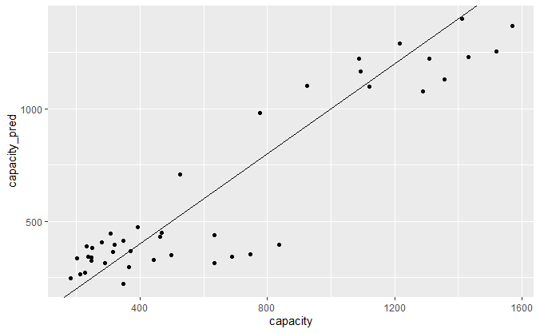

```r
capacity_pred <- data.frame(capacity = exp(OTG_fit_CDSB$model$`log(capacity)`),
                            capacity_pred = exp(OTG_fit_CDSB$fitted.values))

ggplot(capacity_pred,
       aes(x = capacity, y = capacity_pred)) +
  geom_point() +
  geom_abline(intercept = 0, slope = 1)
```

Let’s populate the remaining OTGC in all four school point objects.

The DSB Schools have fields corresponding to grades following this code: ELEM = JKto5 or JKto6 (i.e. Grades.JKto5_6) ELEM + MID = JKto8 (i.e. Grades.JKto8) MID = 6to8 -> (i.e Grades.6to8) HIGH = 9to12 (i.e. Grades.9to12)

The CDSB Schools only have ELEM and HIGH fields.

First, import the rest of the school points:

```r
load("CDSB_1011_Comp.RData")
load("DSB_1516_Comp.RData")
load("CDSB_1516_Comp.RData")
```

Calculate the urban.dist field for all school points:

```r
urban_pt <- st_sfc(st_point(c(-79.869039, 43.256684)), crs=4326 )

DSB_1516_Comp_WSG84 <- st_transform(DSB_1516_Comp, crs=4326)
DSB_1516_Comp$urban.dist <- st_distance(DSB_1516_Comp_WSG84, y = urban_pt)

CDSB_1011_Comp_WSG84 <- st_transform(CDSB_1011_Comp, crs=4326)
CDSB_1011_Comp$urban.dist <- st_distance(CDSB_1011_Comp_WSG84, y = urban_pt)

CDSB_1516_Comp_WSG84 <- st_transform(CDSB_1516_Comp, crs=4326)
CDSB_1516_Comp$urban.dist <- st_distance(CDSB_1516_Comp_WSG84, y = urban_pt)
```

Now add dummy variables for the Grades in all four school point objects.

DSB_1011_OTGC:

```r
#Fill in all the missing values with 0
DSB_1011_Comp <- DSB_1011_Comp %>%
  mutate(ELEM = coalesce(ELEM, "0"),
         MID = coalesce(MID, "0"),
         HIGH = coalesce(HIGH, "0"))

#Create dummy variables correspending to Grades
DSB_1011_OTGC <- DSB_1011_Comp %>%
  mutate(Grades.JKto5_6 = ifelse((ELEM == "ELEM" & MID == "0" & HIGH == "0"), 1, 0),
         Grades.JKto8 = ifelse((ELEM == "ELEM" & MID == "MID" & HIGH == "0") | (SchoolType == "Elementary" & ELEM == "0" & MID == "0" & HIGH == "0"), 1, 0),
         Grades.6to8 = ifelse((ELEM == "0" & MID == "MID" & HIGH == "0"), 1, 0),
         Grades.9to12 = ifelse((ELEM == "0" & MID == "0" & HIGH == "HIGH")|(SchoolType == "Secondary" & ELEM == "0" & MID == "0" & HIGH == "0"), 1, 0))

#add a field with index numbers for merging predicted OTGC
DSB_1011_OTGC$rowID <- 1:nrow(DSB_1011_OTGC)
```

DSB_1516_OTGC:

```r
DSB_1516_OTGC <- DSB_1516_Comp %>%
  mutate(Grades.JKto5_6 = ifelse((Grades == "JK-5" | Grades == "JK-6"), 1, 0),
         Grades.JKto8 = ifelse((Grades == "JK-8"|Grades == "1 to 8"), 1, 0),
         Grades.6to8 = ifelse((Grades == "6 to 8" | Grades == "7 to 8" ), 1, 0),
         Grades.9to12 = ifelse((Grades == "9 to 12"), 1, 0))

DSB_1516_OTGC$rowID <- 1:nrow(DSB_1516_OTGC)
```

CDSB_1011_OTGC:

```r
CDSB_1011_OTGC <- CDSB_1011_Comp %>%
  mutate(Type.Elementary = ifelse(GRADE == "Elementary", 1, 0),
         Type.Secondary = ifelse(GRADE == "Secondary", 1, 0))

CDSB_1011_OTGC$rowID <- 1:nrow(CDSB_1011_OTGC)
```

CDSB_1516_OTGC:

```r
CDSB_1516_OTGC <- CDSB_1516_Comp %>%
  mutate(Type.Elementary = ifelse(GRADE == "Elementary", 1, 0),
         Type.Secondary = ifelse(GRADE == "Secondary", 1, 0))

CDSB_1516_OTGC$rowID <- 1:nrow(CDSB_1516_OTGC)
```

Now predict OTGC using the two models. First, the DSB points:

```r
t <- data.frame(footprint = DSB_1011_OTGC$footprint,
           Grades.JKto5_6 = DSB_1011_OTGC$Grades.JKto5_6,
           Grades.6to8 = DSB_1011_OTGC$Grades.6to8,
           Grades.JKto8 =  DSB_1011_OTGC$Grades.JKto8,
           Grades.9to12 = DSB_1011_OTGC$Grades.9to12,
           urban.dist = DSB_1011_OTGC$urban.dist)
t$urban.dist <- as.matrix(t$urban.dist)

t2 <- predict(OTG_fit_DSB, newdata = t)
t2 <- data.frame(Cap.Output = t2,
                 OTGC = exp(t2))
t2$rowID <- 1:nrow(t2)

DSB_1011_OTGC <- merge(DSB_1011_OTGC, t2, by= "rowID")
```

```r
School_Profiles_u_select <- School_Profiles_u %>%
  select(school_name, capacity)

DSB_1011_OTGC <- DSB_1011_OTGC %>%
  left_join(School_Profiles_u_select, by = c("SCHNAME" = "school_name" ))
```

Let’s do the rest of the school points.

DSB_1516:

```r
t <- data.frame(footprint = DSB_1516_OTGC$footprint,
           Grades.JKto5_6 = DSB_1516_OTGC$Grades.JKto5_6,
           Grades.6to8 = DSB_1516_OTGC$Grades.6to8,
           Grades.JKto8 =  DSB_1516_OTGC$Grades.JKto8,
           Grades.9to12 = DSB_1516_OTGC$Grades.9to12,
           urban.dist = DSB_1516_OTGC$urban.dist)

t$urban.dist <- as.matrix(t$urban.dist)

t2 <- predict(OTG_fit_DSB, newdata = t)
t2 <- data.frame(Cap.Output = t2,
                 OTGC = exp(t2))
t2$rowID <- 1:nrow(t2)

DSB_1516_OTGC <- merge(DSB_1516_OTGC, t2, by= "rowID")
```

CDSB_1011:

```r
t <- data.frame(footprint = CDSB_1011_OTGC$footprint,
           Type.Elementary =  CDSB_1011_OTGC$Type.Elementary,
           Type.Secondary = CDSB_1011_OTGC$Type.Secondary,
           urban.dist = CDSB_1011_OTGC$urban.dist)

t$urban.dist <- as.matrix(t$urban.dist)

t2 <- predict(OTG_fit_CDSB, newdata = t)

t2 <- data.frame(Cap.Output = t2,
                 OTGC = exp(t2))
t2$rowID <- 1:nrow(t2)

CDSB_1011_OTGC <- merge(CDSB_1011_OTGC, t2, by= "rowID")
```

CDSB_1516:

```r
t <- data.frame(footprint = CDSB_1516_OTGC$footprint,
           Type.Elementary =  CDSB_1516_OTGC$Type.Elementary,
           Type.Secondary = CDSB_1516_OTGC$Type.Secondary,
           urban.dist = CDSB_1516_OTGC$urban.dist)

t$urban.dist <- as.matrix(t$urban.dist)

t2 <- predict(OTG_fit_CDSB, newdata = t)

t2 <- data.frame(Cap.Output = t2,
                 OTGC = exp(t2))
t2$rowID <- 1:nrow(t2)

CDSB_1516_OTGC <- merge(CDSB_1516_OTGC, t2, by= "rowID")
```

Save as .RData:

```r
saveRDS(DSB_1011_OTGC, "DSB_1011_OTGC.RData")
saveRDS(CDSB_1011_OTGC, "CDSB_1011_OTGC.RData")

saveRDS(DSB_1516_OTGC, "DSB_1516_OTGC.RData")
saveRDS(CDSB_1516_OTGC, "CDSB_1516_OTGC.RData")
```